# Comments for MEDB 5502, Module 01

## Topics to be covered

- What you will learn
  - Syllabus
  - Linear regression with one continuous variable
  - Linear regression with one binary categorical variable
  - Live demo, part 1
  - Logistic regression with one continuous independent variable
  - Logistic regression with one binary categorical variable
  - Live demo, part 2

## Syllabus

You can find the [syllabus](https://github.com/pmean/classes/blob/master/syllabi/2026-medb-5502-syllabus.md) for this class on my [github site](https://github.com/pmean).

## Break #1

- What you have learned
  - Syllabus
- What’s coming next
  - Linear regression with one continuous variable

## Linear regression interpretation of a straight line

- Regression equation
  - $Y_i=\beta_0+\beta_1 X_i+\epsilon_i$
- The slope represents the estimated average change in Y when X increases by one unit.
- The intercept represents the estimated average value of Y when X equals zero.
- Terminology
  - X is the independent or predictor variable
  - Y is the dependent or outcome variable

## Simple regression example with interpretation, 1

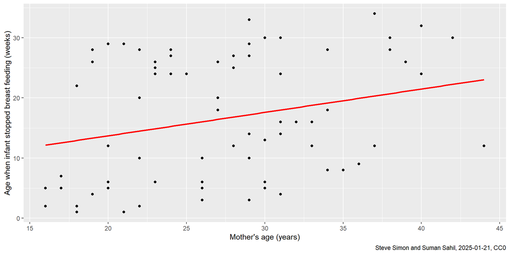

## Simple regression example with interpretation, 2

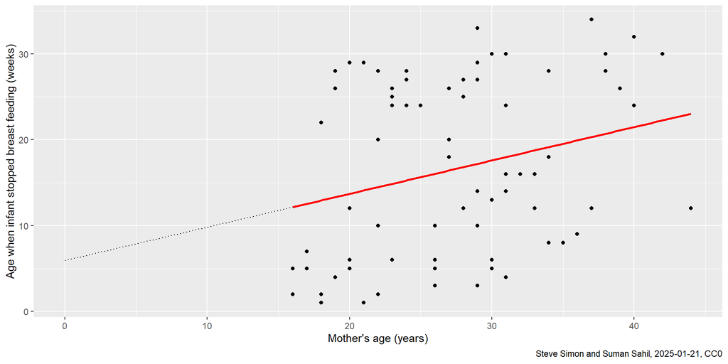

## Simple regression example with interpretation, 3

```
# A tibble: 2 × 5
  term        estimate std.error statistic p.value
  <chr>          <dbl>     <dbl>     <dbl>   <dbl>
1 (Intercept)    5.92      4.58       1.29  0.200
2 mom_age        0.389     0.162      2.40  0.0188
```

## Predicted values, 1

- How long would you expect a 20 year old mom to breast feed?

```
# A tibble: 5 × 2
  mom_age age_stop
    <dbl>    <dbl>
1      20        5
2      20       29
3      20        6
4      20       NA
5      20       12
```

## Predicted values, 2

- For an existing value in the data, $X_i$
  - $\hat{Y}_i=b_0+b_1 X_i$
- For a new value of X
  - $\hat{Y}_{new}=b_0+b_1 X_{new}$
  - Do not predict outside the range of X values

## Why predict for a value you already have seen?

- Future Y may differ from previous Y
- $\hat{Y}_i$ is more precise
- Comparison of $\hat{Y}_i$ to existing $Y_i$.

## Predicted values, 3

Predicted age_stop = 5.92 + 0.389*20 = 13.7

```
# A tibble: 1 × 2
  mom_age .fitted
    <dbl>   <dbl>
1      20    13.7
```

## Residuals, 1

- $e_i=Y_i-\hat{Y}_i$
  - Residual = Observed - Predicted
- Very helpful in assessing assumptions

## Residuals, 2

```
# A tibble: 4 × 5
  .rownames mom_age age_stop .fitted .resid
  <chr>       <dbl>    <dbl>   <dbl>  <dbl>
1 8              20        5    13.7  -8.70
2 40             20       29    13.7  15.3
3 44             20        6    13.7  -7.70
4 67             20       12    13.7  -1.70
```

## Break #2

- What you have learned
  - Linear regression with one continuous variable
- What’s coming next
  - Linear regression with one binary categorical variable

## Categorical independent variables, 1

- Regression equation
  - $Y_i=\beta_0+\beta_1 X_i+\epsilon_i$
- How do you modify this if $X_i$ is categorical?
  - Indicator variables
- Examples
  - Treatment: active drug=1, placebo=0
  - Second hand smoke: exposed=1, not exposed=0
  - Gender: male=1, female=0
- To be discussed later: three of more category levels

## Categorical independent variables, 2

- If $X_i$ = 0
  - $Y_i=\beta_0 + \beta_1 (0) + \epsilon_i$
  - $Y_i=\beta_0 + \epsilon_i$
- If $X_i$ = 1
  - $Y_i=\beta_0 + \beta_1 (1) + \epsilon_i$
  - $Y_i=\beta_0 + \beta_1 + \epsilon_i$

## Categorical independent variables, 3

- Intperetation
  - $b_0$ is the estimated average value of Y when X equals the “zero category”
  - $b_1$ is the estimated average change in Y when X changes from the “zero category” to the “one category.”

## Creating an indicator variable

```
# A tibble: 6 × 3
  feed_type age_stop i_treatment
  <chr>        <dbl>       <dbl>
1 Treatmen        30           1
2 Treatmen         4           1
3 Control         12           0
4 Treatmen        29           1
5 Control         24           0
6 Control         24           0
```

## Graphical display using the indicator variable

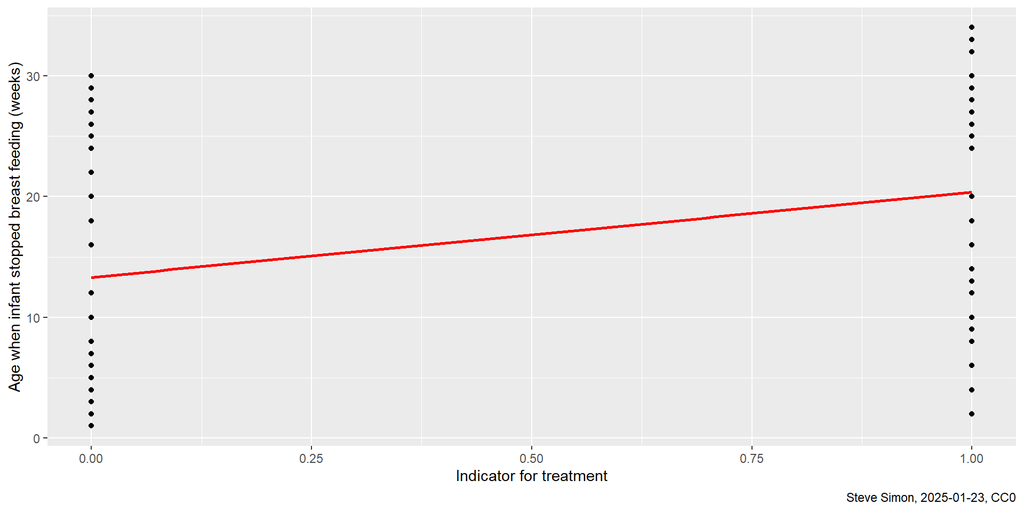

## Linear regression using the indicator variable

```
# A tibble: 2 × 5
  term              estimate std.error statistic  p.value
  <chr>                <dbl>     <dbl>     <dbl>    <dbl>
1 (Intercept)          13.3       1.46      9.13 4.78e-14
2 feed_typeTreatmen     7.05      2.14      3.29 1.48e- 3
```

## Graphical display using alternate indicator variable

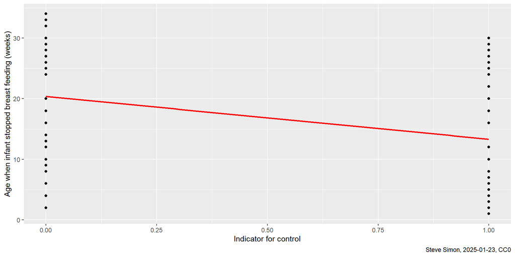

## Letting your software create the indicator variable

- Different rules for different software
  - SPSS, SAS: first alphabetical category=1, second=0
  - R: second alphabetical category=1, first=0
- Always compare your output to the descriptive statistics

## Break #3

- What you have learned
  - Linear regression with one binary categorical variable
- What’s coming next
  - Live demo, part 1

## Live demo, part 1

Review part 1 of the [output](https://github.com/pmean/classes/blob/master/biostats-2/01/results/simon-5502-01-demo.html) from simon-5502-01-demo.

## Break #4

- What you have learned
  - Live demo, part 1
- What’s coming next
  - Logistic regression with one continuous independent variable

## Probability

- Binary outcome
  - n1 successes
  - n2 failures
- Probability = n1 / (n1+n2)
  - Always between 0 and 1

## Odds

- Odds = n1/n2
  - Always between 0 and +$\infty$
- Log-odds = log(n1/n2)
  - Traditional to use natural logarithm (base e)
  - Always between -$\infty$ and +$\infty$

## Logistic regression

- Linear on a log-odds scale
  - Impossible to produce an invalid response
- Back transform
  - Odds = exp(log-odds)
  - Probability = Odds / (1 + Odds)

## Interpretation of logistic regression coefficient

- Intercept: estimated log odds when X=0
  - Often an extrapolation
- Slope: estimated average change in log-odds
  - When x increases by one unit
  - Equivalent to a log odds ratio

## Untransformed logistic regression coefficients

```
# A tibble: 2 × 5
  term        estimate std.error statistic  p.value
  <chr>          <dbl>     <dbl>     <dbl>    <dbl>
1 (Intercept)  -2.38      0.636      -3.74 0.000183
2 dc_age        0.0336    0.0151      2.23 0.0256
```

## Transformed logistic regression coefficients

```
# A tibble: 2 × 6
  term        estimate std.error statistic  p.value transformed_estimate
  <chr>          <dbl>     <dbl>     <dbl>    <dbl>                <dbl>
1 (Intercept)  -2.38      0.636      -3.74 0.000183               0.0925
2 dc_age        0.0336    0.0151      2.23 0.0256                 1.03
```

## Prediction from a logistic regression model

- log-odds = -2.38 + 40 $\times$ 0.034 = -1.034
- odds = exp(-1.034) = 0.356
- probability = 0.356 / (1 + 0.356) = 0.262

## Break #5

- What you have learned
  - Logistic regression with one continuous independent variable
- What’s coming next
  - Logistic regression with one binary categorical variable

## Binary independent variable

- Slight change in interpretation
- Intercept: estimated log odds for 0 category
- Slope: estimated log odds ratio
  - comparing 0 category to 1 category

## Untransformed logistic regression coefficients

```
# A tibble: 2 × 5
  term        estimate std.error statistic p.value
  <chr>          <dbl>     <dbl>     <dbl>   <dbl>
1 (Intercept)    0.103     0.788     0.131   0.896
2 del_type      -0.870     0.532    -1.64    0.102
```

## Transformed logistic regression coefficients

```
# A tibble: 2 × 6
  term        estimate std.error statistic p.value transformed_estimate
  <chr>          <dbl>     <dbl>     <dbl>   <dbl>                <dbl>
1 (Intercept)    0.103     0.788     0.131   0.896                1.11
2 del_type      -0.870     0.532    -1.64    0.102                0.419
```

## Calculation of odds ratio from crosstabulation, 1

```
          Continued bf Stopped bf
Vaginal             28         13
C-section           36          7
```

## Calculation of odds ratio from crosstabulation, 1

- Odds_vaginal = 13 / 28 = 0.464
- Odds_csection = 7 / 36 = 0.194
- Odds_ratio = 0.194 / 0.464 = 0.419

## Break #6

- What you have learned
  - Logistic regression with one binary categorical variable
- What’s coming next
  - Live demo, part 2

## Live demo, part 2

Review part 2 of the [output](https://github.com/pmean/classes/blob/master/biostats-2/01/results/simon-5502-01-demo.html) from simon-5502-01-demo.

## Summary

- What you have learned
  - Syllabus
  - Linear regression with one continuous variable
  - Linear regression with one binary categorical variable
  - Live demo, part 1
  - Logistic regression with one continuous independent variable
  - Logistic regression with one binary categorical variable
  - Live demo, part 2